# Introduction

## Give the context – why is this an interesting topic?

As we were brainstorming topic ideas for this project, we wanted to explore data sets on topics that we collectively thought were interesting to both research and analyze. Therefore, we decided to study data and base our project on UFO sightings and additionally its relationship with population density in the cities with high numbers of sightings. This is a topic that interests us because there are lots of conspiracies and controversies with UFOs which not only make it more fun for us to analyze, but it also can be interesting for the people viewing our data and findings.

## What do we already know about this topic?

From our previous knowledge and further research on this topic, we know that there is no clear conclusion on whether the number of UFO sightings has any direct correlation to the population of that city/state. However, with this given knowledge, as we were gathering our data and compiling our findings, we assumed that in cities/states where the population is higher, there would likely be more UFO sightings reported. Furthermore, as students who are frequently on social media where UFO sightings are both reported and discussed, we are subject to a broader cultural fascination on this topic.

## Explain what exactly you are doing (as questions you want to answer or stories you want to tell)

Prior to the technical portion of our project, we created three questions relating to our observations that we wanted to further explore.

Question 1: How does the population size of a particular city/state affect the number of UFO sightings? With our curiosity on aliens, we wanted to explore the possibility of population being a causation of UFO sightings.

Question 2: How does the light pollution of a city/state affect the potentiality and likelihood of a UFO sighting? In densely populated cities/states, we assumed that UFOs would be more difficult to notice due to the large amount of light polluting the sky.

Question 3: Does a state being on the coast or not play a role in the number of UFO sightings? We want to see if the location of a state impacts the number of UFO sightings.

In order to conduct our observations on the relationship between UFO sightings and US cities/states, we created tables and graphs, with datasets that we found online, through RStudio to visually represent our findings. With these tables, graphs, and analysis, we observed any patterns that would help us answer our questions.

## Explain why it is interesting – why care? why read our report?

We believe our findings are interesting because the general topic of UFOs and aliens still remains a relative mystery to the public. Combining two datasets, like the ones we used, and creating visual diagrams opens up possibilities to discover correlations and other patterns that can incline further interest in this topic and help understand the relationship between factors like population and UFO sightings. WIth our report, it shows correlations in a way that is simple enough for people to understand and interpret without much effort.

With 42% of Americans believing that UFOs do exist and one in ten Americans having allegedly witnessed a UFO, people should care about our report because it can promote a more nuanced understanding of such a wide topic.

https://www.ipsos.com/en-us/many-americans-believe-supernatural-ufos

# Explain Your Data

## Why do you use these datasets?

We used these specific datasets, UFOs_coord and us-cities-top-1k, because it provided detailed information that would help us expand our observations such as the specific latitude and longitude of each UFO sighting along with the specific time of each UFO sighting and the latitude and longitude of each city in the US population dataset. The incorporation of such precise data not only allows us to increase the context of our study but also allows us to perform a more in-depth analysis of potential patterns and correlations associated with our topic. Furthermore, for each sighting in our UFO sightings dataset, a short witness description of the UFO that was spotted is even included. Though we did not use the data of the descriptions, it shows the abundance of information that was provided from just one dataset.

## Where did your datasets originate from?

For our UFO sightings dataset, we found the dataset on Kaggle, a platform where data scientists come together.

For our US population dataset, we found the dataset on GitHub, a platform where people can post codes and collaborate with each other.

## Who collected data?

The data shown in the dataset is collected by people self-reporting their UFO sightings.

The data shown in this dataset is derived from the US census.

## Is the data freely available for everyone? Any restrictions?

The datasets utilized for our project are freely available for everyone, highlighting the platforms' open access to information. While it is recommended to create an account for both platforms, Kaggle and GitHub, it is not required for searching and accessing datasets. The datasets that are provided on both of these platforms are able to be used for various interests and applications whether it be for research, projects, data analysis, and much more. Data that is accessible to everyone encourages people to explore their interests, like we did, by combining them to find correlations that reveal patterns and further discoveries.

## What are the datasets about? What is the population and sample?

The population of our UFO sightings dataset is the people who have reported their sightings of UFOs. The samples within our UFO sightings dataset span key statistical indicators for each sighting such as date, time, city, witness description, and exact coordinates of the sighting.

The population of our US population dataset would be all of the cities in the United States. The samples within the US population dataset would be the US cities that actually have records of UFO sightings, which we used to conduct further observations.

## Discuss any data quality issues you encountered

We did not encounter any issues with the quality of our data. With the plethora of information within the datasets, there was no further information we needed that was not provided by the datasets we used.

## What do rows represent in your final dataset?

In our final dataset, rows represent a singular state, with its population and number of sightings, as well as whether or not the state is a coastal state.

## How many observations do you have?

In our original dataset, we had over 6,000 observations. We cleaned up the data to summarize all of the sightings per state, and subsequently merged them with a file taken from the Department of Commerce. Thus, our final dataset only has 50 rows or observations, each representing a single state, with the number of sightings and the population, as well as whether or not the state is a coastal state.

## What are the relevant variables and how are they coded?

The relevant variables are the state, the population, the number of sightings, and whether or not the state is coastal. State is coded as a <chr>, population as a double, sightings as a double, and IsCoastal is coded as a boolean.

## Any missing, non-plausible values, or other quality issues in the relevant variables? How many?

No. We double checked the original code and there were no missing variables or any signs to indicate that our data might be deficient in quality. Note, our original observations contained sightings from both Canada and the United States. Our final cleaned dataset contains information only pertaining to the United States. We decided to omit the data from Canada as the frequency of observations was simply too low in comparison to the US, and thus wouldn't provide high-level insights or analysis for us.

# Discuss Your Methods

## Which variables did you include? Why?

Since we utilized different versions of the same dataset to answer different questions, I'll explain all the variables that were necessary. City, state, latitude, and longitude were most important for our generation of the graph. These all corresponded to a different point that was mapped onto the leaflet graph. Secondly, we summarized all the sightings for each state, so this was a variable that we introduced. Lastly, we utilized the population of each state (taken from a new dataset), and determined whether or not a state is coastal as a new variable as well.

## How did you process your data? Why?

We read the csv files for each dataset and merged them afterwards. The processing of the files was not too difficult since most of the datasets contained no missing values or difficult data types. Merging the dataset by "state" was done to allow for the summarization of all values within the dataset, and allowed for us to create visualizations for sightings by state.

## How did you select your sample?

The sample that we utilized in the end was only information captured in the US. While our dataset initially contained information from Canada as well, we found this to be redundant for some of our questions later on, as the number of sightings in the Canadian area was simply too low for any analysis or interpretation.

## Any technical decisions you did (remove or replace missing values)?

The most technical decision that we did was removing the Canada values. Another decision that we decided was to utilize population data for each state. While we initially only wanted to use two datasets, it proved to be difficult having a correlation between state population and the number of sightings with only information taken from the city populations.

## Discuss more complex statistical methods (ie. regression), if used.

Regression was utilized to determine a correlation between the population of a state and the total number of sightings. For instance, when we determined that California had the most sightings by a significant margin, we wondered if this was an outlier or simply due to California's large population. After performing a regression on the stat plot of sightings vs. state population, we found that population alone explained 71.39% of the variation seen in sightings (R squared value was 0.7139). Given that other variables such as a state's demographic and age range could account for the other variation seen, it's likely that California isn't necessarily a UFO sighting hotspot, and simply has the most sightings due to its large population.

# **Results**

We examined the relationship between UFO sightings and the population of US cities to observe any possible correlation. By plotting our data into multiple types of graphs, to visualize our data in various ways, we were able to make some notable insights. First, we plotted our data into a map of the United States in order to see where on the US map UFOs are mainly seen. Second, we created two bar graphs to visualize the number of UFO sightings per state. One bar graph containing all 50 US states and another one containing the top 10 US states with the most UFO sightings. Third, we constructed a scatter plot of the two datasets to show the relationship between the total sightings in each state and the population of those states. Lastly, we created one more bar graph that shows the total number of UFO sightings by coastal and non-coastal states. Overall, we found that the relationship between UFO sightings and population is proportionate. The higher the population of a state/city, the more UFO sightings there will be. We also found that states that are on the coast relatively have more reported UFO sightings.

## figure 1

```r
library(leaflet)
library(leaflet.extras)
library(tidyverse)
ufo_data <- read_delim("UFOs_coord.csv")
ufo_data$City <- iconv(ufo_data$City, to = "UTF-8", sub = "")

customIcon <- makeIcon(
  iconUrl = "https://pngimg.com/uploads/dot/dot_PNG7.png",
  iconWidth = 5, iconHeight = 5,
)

#
ufo_map <- leaflet(ufo_data) %>%
  addTiles() %>%
  addMarkers(~lng, ~lat, popup = ~City, icon = customIcon)

ufo_map
```

[interactive chart not shown]

From figure 1, we observed that even though all states have at least one UFO sighting, at a glance, certain states have higher levels of sightings than others. We also noticed that the sightings seem to be aligned with the population spread of the US. For example, looking at the map, we can see that the midwest and central US have lower sightings as they have lower population. By looking at our map, we can also see that the states on the coast tend to have more sightings than non coastal states.

## figure 2

### bar plot 1:

```r
library(ggplot2)
library(dplyr)
library(tidyverse)
census <- read_delim("us-cities-top-1k.csv") %>%
  select(City, Population)
merged_data <-merge(census, ufo_data, by ="City")
head(merged_data)
```

```
##      City Population         Date / Time Country State     Shape
## 1 Abilene     120099       5/29/16 21:45     USA    TX     Light
## 2   Akron     198100 2016-06-02 21.30.00     USA    OH     Light
## 3   Akron     198100       6/29/16 23:00     USA    OH    Circle
## 4   Akron     198100       9/24/16 22:00     USA    OH Formation
## 5 Alameda      76419 2016-07-07 00.40.00     USA    CA   Unknown
## 6  Albany      76185 2016-01-11 05.00.00     USA    NY     Light
##                                                                                                                                     Summary
## 1                                                                                            White light that makes quick 360 degree turns.
## 2                                                                                20-30 multicolored fast moving orbs seen over Akron, Ohio.
## 3 My boyfriend and I were having a bonfire when he noticed a strange object \nin the sky moving east; it looked as though it was on fire bu
## 4 I saw 4 amber glowing disk shaped objects very low to the ground over \nMerriman Valley. I was driving so it was difficult to watch. Very
## 5                                                         Saw green flashing or lightning twice in a minute. I woke up and saw 2 \nflashes.
## 6            Star-like orange object that could move in a way I've never seen before - \nthat emitted smaller objects and have them return.
##        lat        lng
## 1 32.44645  -99.73335
## 2 41.08306  -81.51849
## 3 41.08306  -81.51849
## 4 41.08306  -81.51849
## 5 37.60903 -121.89914
## 6 42.65117  -73.75497
```

```r
filtered <- merged_data %>%
  select(City, Population, Country, State)
head(filtered)
```

```
##      City Population Country State
## 1 Abilene     120099     USA    TX
## 2   Akron     198100     USA    OH
## 3   Akron     198100     USA    OH
## 4   Akron     198100     USA    OH
## 5 Alameda      76419     USA    CA
## 6  Albany      76185     USA    NY
```

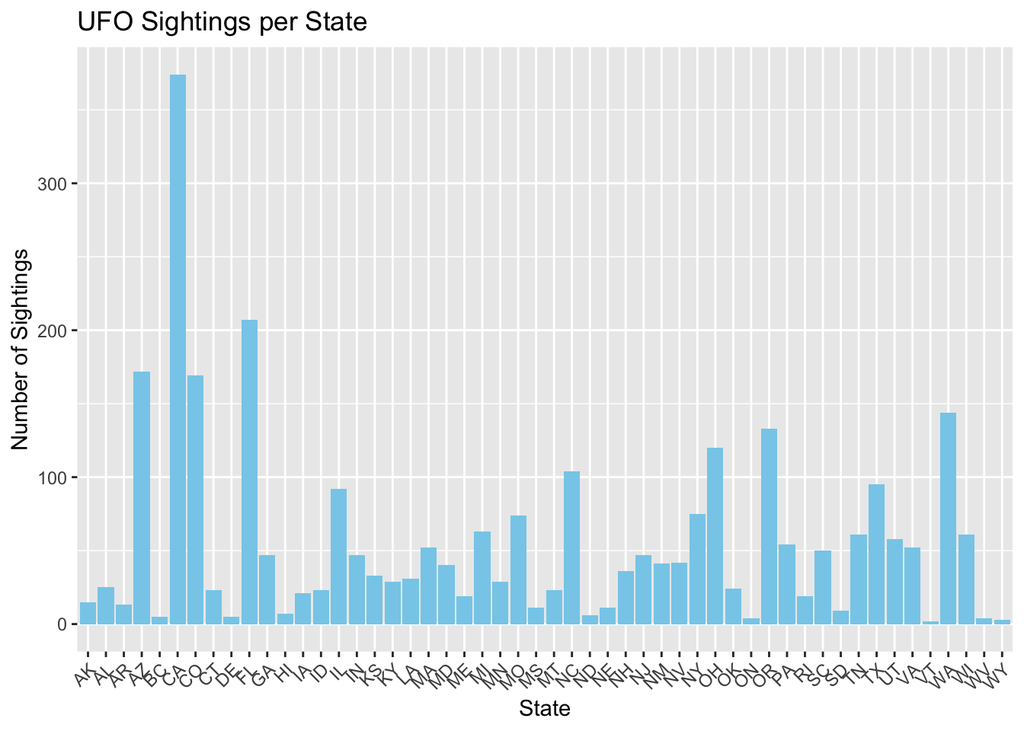

```r
ufo_data_summary <- filtered %>%
  group_by(State) %>%
  summarize(Sightings = n())
my_plot <- ggplot(ufo_data_summary, aes(x = State, y = Sightings)) +
  geom_col(fill = "skyblue") +
  labs(title = "UFO Sightings per State", x = "State", y = "Number of Sightings") +
  theme(axis.text.x = element_text(angle = 45, hjust = 1))
print(my_plot)
```

### bar plot 2:

```r
census <- read_delim("us-cities-top-1k.csv")
```

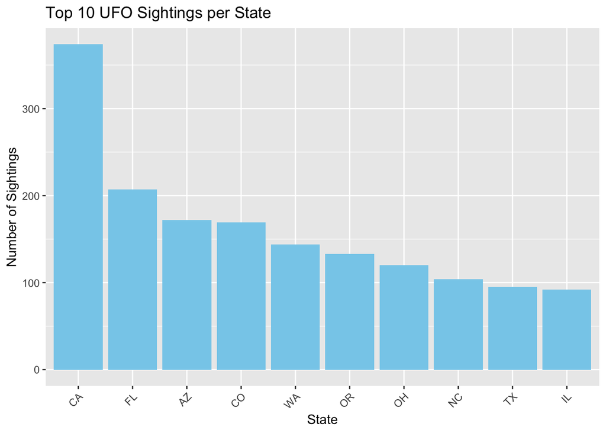

```r
ufo_data_summary <- filtered %>%
  group_by(State) %>%
  summarize(Sightings = n()) %>%
  arrange(desc(Sightings)) %>%
  slice_head(n = 10)

merged_data <- merge(ufo_data_summary, census, by = "State", all.x = TRUE)

my_plot <- ggplot(ufo_data_summary, aes(x = reorder(State, -Sightings), y = Sightings)) +
  geom_col(fill = "skyblue") +
  labs(title = "Top 10 UFO Sightings per State", x = "State", y = "Number of Sightings") +
  theme(axis.text.x = element_text(angle = 45, hjust = 1))

print(my_plot)
```

From figure 2, the first we noticed was that California is the state with the most UFO sightings. However, California is also the most populated US state which corresponds to its high number of sightings. We also noticed that after the top 10 states, the number of sightings for the rest of the states does not go above 100.

### figure 3

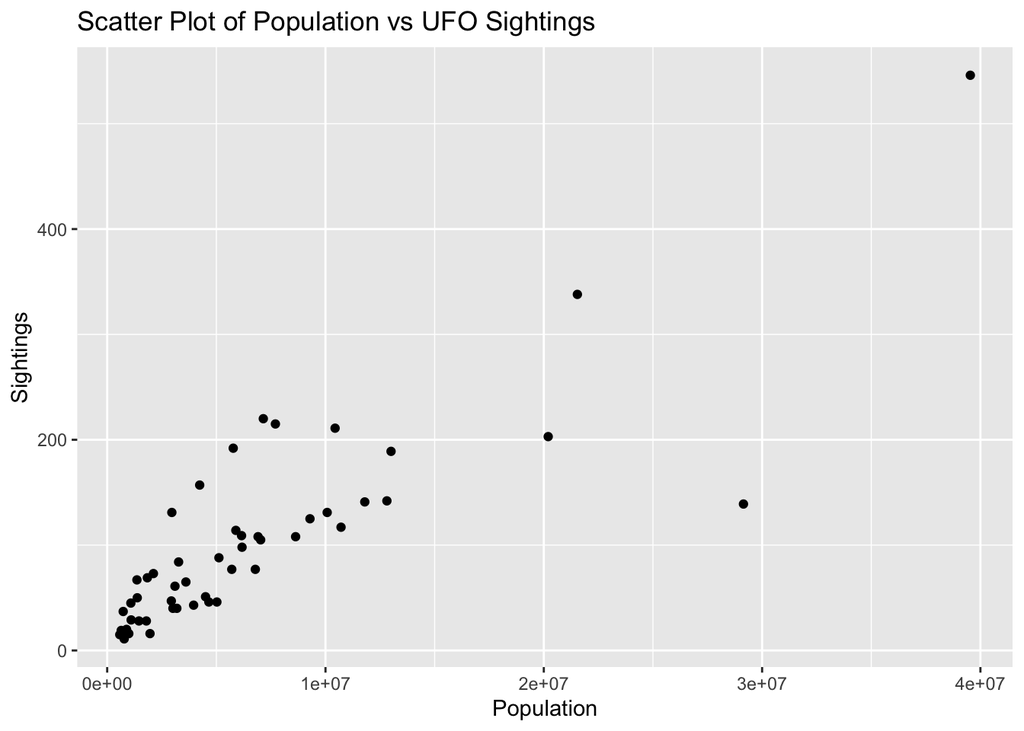

```r
library(readxl)
ufo_sightings_by_state <- read_excel("DEPTOFCOMMERCESTATEPOPULATIONDATA.xlsx")
ggplot(ufo_sightings_by_state, aes(x = Population, y = Sightings)) +
  geom_point() +
  labs(title = "Scatter Plot of Population vs UFO Sightings",
       x = "Population",
       y = "Sightings")
```

```r
model <- lm(Sightings ~ Population, data = ufo_sightings_by_state)
summary(model)
```

```
##
## Call:
## lm(formula = Sightings ~ Population, data = ufo_sightings_by_state)
##
## Residuals:
##      Min       1Q   Median       3Q      Max
## -203.147  -25.642   -7.167   17.195  111.756
##
## Coefficients:
##              Estimate Std. Error t value Pr(>|t|)
## (Intercept) 3.219e+01  9.617e+00   3.347   0.0016 **
## Population  1.063e-05  9.717e-07  10.944 1.22e-14 ***
## ---
## Signif. codes:  0 '***' 0.001 '**' 0.01 '*' 0.05 '.' 0.1 ' ' 1
##
## Residual standard error: 50.58 on 48 degrees of freedom
## Multiple R-squared:  0.7139, Adjusted R-squared:  0.7079
## F-statistic: 119.8 on 1 and 48 DF,  p-value: 1.217e-14
```

```r
head(ufo_sightings_by_state)
```

```
## # A tibble: 6 × 3
##   State      Population Sightings
##   <chr>           <dbl>     <dbl>
## 1 Alabama       5024279        46
## 2 Alaska         733391        37
## 3 Arizona       7151502       220
## 4 Arkansas      3011524        40
## 5 California   39538223       546
## 6 Colorado      5773714       192
```

### figure 4

```r
print(ufo_sightings_by_state)
```

```
## # A tibble: 50 × 3
##    State       Population Sightings
##    <chr>            <dbl>     <dbl>
##  1 Alabama        5024279        46
##  2 Alaska          733391        37
##  3 Arizona        7151502       220
##  4 Arkansas       3011524        40
##  5 California    39538223       546
##  6 Colorado       5773714       192
##  7 Connecticut    3605944        65
##  8 Delaware        989948        16
##  9 Florida       21538187       338
## 10 Georgia       10711908       117
## # ℹ 40 more rows
```

```r
coastal_states <- c(
  "Alabama", "Alaska", "California", "Connecticut", "Delaware", "Florida",
  "Georgia", "Hawaii", "Louisiana", "Maine", "Maryland", "Massachusetts",
  "Mississippi", "New Hampshire", "New Jersey", "New York", "North Carolina",
  "Oregon", "Rhode Island", "South Carolina", "Texas", "Virginia", "Washington"
)
ufo_sightings_by_state$IsCoastal <- ifelse(ufo_sightings_by_state$State %in% coastal_states, TRUE, FALSE)

# Print the updated data
print(ufo_sightings_by_state)
```

```
## # A tibble: 50 × 4
##    State       Population Sightings IsCoastal
##    <chr>            <dbl>     <dbl> <lgl>
##  1 Alabama        5024279        46 TRUE
##  2 Alaska          733391        37 TRUE
##  3 Arizona        7151502       220 FALSE
##  4 Arkansas       3011524        40 FALSE
##  5 California    39538223       546 TRUE
##  6 Colorado       5773714       192 FALSE
##  7 Connecticut    3605944        65 TRUE
##  8 Delaware        989948        16 TRUE
##  9 Florida       21538187       338 TRUE
## 10 Georgia       10711908       117 TRUE
## # ℹ 40 more rows
```

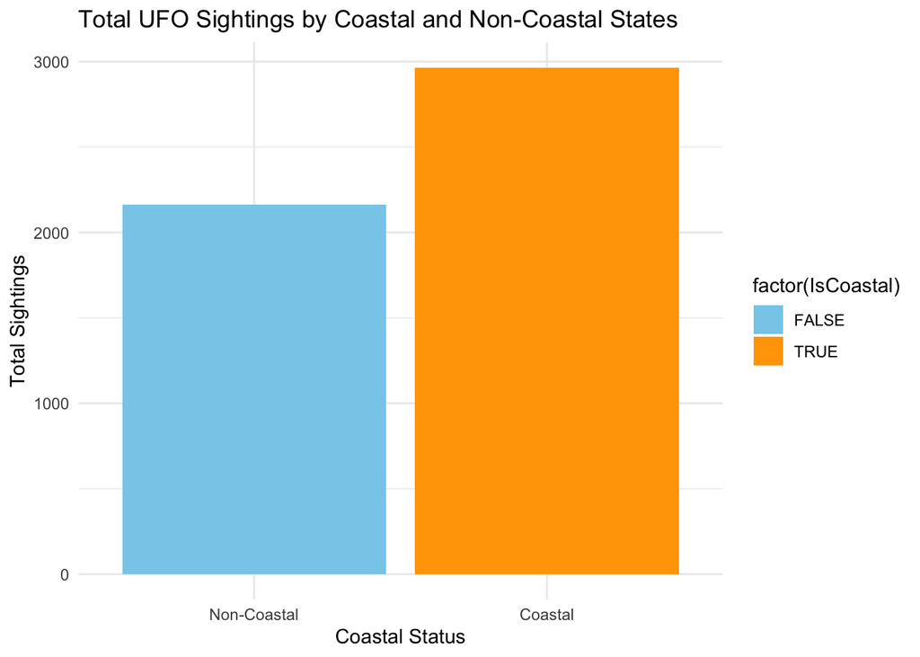

```r
library(ggplot2)

sightings_summary <- ufo_sightings_by_state %>%
  group_by(IsCoastal) %>%
  summarise(TotalSightings = sum(Sightings))

ggplot(sightings_summary, aes(x = factor(IsCoastal, labels = c("Non-Coastal", "Coastal")), y = TotalSightings, fill = factor(IsCoastal))) +
  geom_bar(stat = "identity", position = "dodge") +
  labs(title = "Total UFO Sightings by Coastal and Non-Coastal States",
       x = "Coastal Status",
       y = "Total Sightings") +
  scale_fill_manual(values = c("FALSE" = "skyblue", "TRUE" = "orange")) +
  theme_minimal()
```

Our graphs demonstrate that population explains roughly 70% of the variation for the total number of sightings. The r^2 value allows us to conclude that there is some type of correlation between UFO sightings and population.

# **Discuss Your Findings**

## Give directions for future work – what analysis/data you might need to extend your story further?

With our lack of information on UFOs and aliens in general, it is difficult to discover any direct causes for UFO sightings with the datasets that we used. Alternatively, we were still able to find patterns within our data that could prompt further exploration on this topic. In order for us to be able to presume any possible causation, we would need to broaden our scope of variables and factors other than solely population and conduct much more research scanning a variety of subjects. Some variables and factors that would help us expand our analysis are cultural beliefs and regional/geographical factors.

# **Summary**

Exploring the topic of UFOs, through this project we were able to study its connection to the population and location of states and whether or not we can draw any definite conclusions. As such an intriguing topic, it captivates the intersection of data analysis and phenomena that we want to learn more about. We developed research questions that delve into the effects of population size, whether the location of a state (coastal or non-coastal) plays a role in the number of sightings, and even the effects of light pollution. This analysis is about uncovering various connections between UFO sightings and population in the US for the millions of Americans that take interest in this topic like we do.

For the datasets utilized, we found one from Kaggle that consists of US UFO sightings with the precise time, date, latitude and longitude of the sighting, city, state, and even a brief description of the UFO. The other dataset that we obtained from GitHub consists of the population of each US city. With freely accessible datasets from reliable platforms, we were able to select the variables we wanted to use and merge them together to create our final dataset which was the main resource of our analysis.

Our methods involved cleaning, filtering relevant variables, and merging them through the city name. We selected variables like city, population, state, country, date, and number of sightings as they are relevant to our research questions.

With many limitations to our study, our findings still open up paths of curiosity, further exploration, and continued research considering a multitude of factors to reveal the complex web surrounding UFO sightings. Our project serves as a stepping stone toward a more comprehensive exploration of the ongoing understanding of UFOs.